# Testing Independence between Networks and Attributes

Youjin Lee

- Local Distance Correlation
- Diffusion Distance
- Univariate Attributes
- Multivariate Attributes
- Locally Dependent Model

Throughout our work, we are interested in testing independence between network $G$ and its nodes’ ($V(G)$) attribute $Y$.

$H_{0} : f_{G \cdot Y} = f_{G} \cdot f_{Y}$

## Local Distance Correlation

Global distance covariance which is used to measure the distances between two random variables $X \in \mathcal{R}^{p}$ and $Y \in \mathcal{R}^{q}$ is defined as follows:

$dCov_{n}(X,Y) = \frac{1}{n^2} \sum\limits_{i,j=1}^{n} A^{H}_{ij} B^{H}_{ij}$

where $A^{H} = HAH; A_{ij} = \parallel X_{i} - X_{j} \parallel ; H = I_{n} - J_{n} / n.$ Sample distance correlation is obtained through normalization. It is known that as $n \rightarrow \infty,$ the sample distance correlation, called dCor coverages to 0 if and only if $X$ and $Y$ are independent each other. Unfortunately, however, simulation results show that dCor performs worse if $X$ or $Y$ is high-dimensional. Now we suggest using local distance covariance instead:

$dCov_{kl}(X,Y) = \frac{1}{n^2} \sum\limits_{i,j}^{n} A^{H}_{ij} B^{H}_{ij} I(r(A_{ij}) < k) I(r(B_{ij}) < l )$

where $r(A_{ij}) = k$ if and only if $A_{ij}$ is the $k^{th}$ smallest distance in $\{ A_{ij} ; i,j=1,..,n , i \neq j \}.$

## Diffusion Distance

The distance correlation(dCor) $\mathcal{R}^2$ between random vectors $X$($\in \textbf{R}^{p}$) and $Y(\in \textbf{R}^{q})$ is defined based on Euclidean distance between two. In the contexts of network, if node attributes vector $Y$ is all continuous, we can think its distance matrix, but we cannot intuitively think of Euclidean distance for their underlying networks. It is known that a dissimilarity matrix $\Delta$ is a Type-2 Euclidean distance matrix if and only if $\tau(\Delta)$ is positive definite, where $\tau(A) = -\frac{1}{2}(I - 1 1^{T} / n) A (I - 1 1^{T} / n).$ Based on this, we suggest diffusion distance as a distance matrix corresponding to Euclidean distance matrix for network. Diffusion distance at time $t$ between two nodes can be measured as the dissimilarity of two in the network space with connectivity between them at $t$ step. Let me introduce some notations.

- Similarity measure $\omega$

$\omega[i,j] = \mbox{ (the number of synapses starting from i to j)}$

- Transition probability (Assume time homogeneous Markov chain; left stochastic matrix)

$P[i,j] = Pr\big( X_{n} = j | X_{n-1} = i \big)$

We define the transition matrix = $(p_{ij})$ of a Markov chain as:

$p_{ij} = \left\{ \begin{array}{ll} \frac{w(\{ i, j\})}{ deg(i) } & \mbox{ if } u \sim v \\ 0 & \mbox{ otherwise } \end{array} \right.$

That is,

$P[i,j] = \frac{\mbox{Number of edges between i and j}}{ \mbox{Degree of node i} }$

- Stationary distribution : A probability vector $\pi$ is a stationary distribution for Markov chain $P$ if $\pi P = \pi$. Over the long run, no matter what the starting state was, the proportion of time the chain spends in node $j$ is approximately $\pi(j) (j = 1, ... , n)$.

Let $G = (V, E, \omega)$ be an undirected graph with $\omega$ being a similarity measure between vertices of $V.$ Denote by $\textbf{P}$ the probability transition matrix of $G.$ The diffusion distance at time $t,$ $\rho_{t}(u,v)$, between two nodes $u,v \in V$ is defined as:

$\rho^2_{t} = \sum\limits_{w \in V}\big( \textbf{P}^{t}(u,w) - \textbf{P}^{t}(v,w) \big)^2 \frac{1}{\pi(w)} = \kappa(\textbf{P}^{2t} \Pi^{-1} )$

If $C$ is a distance matrix of graph $G$:

$C_{t}[i,j] = \sum\limits_{w \in V(G)}\big( \textbf{P}^{t}[i,w] - \textbf{P}^{t}[j,w] \big)^2 \frac{1}{\pi(w)}$

Diffusion distances for Directed Graph at time $t$ is defined as :

$\Delta_{\rho^{2}_{t}} = \kappa(\textbf{P}^{t} \Pi^{-1} (\textbf{P}^{t})^{T} )$

where $\kappa(\textbf{A}) = \textbf{A}_{dg} \textbf{1} \textbf{1}^{T} - \textbf{A} - \textbf{A}^{T} + \textbf{1} \textbf{1}^{T} \textbf{A}_{dg}$

## Univariate Attributes

Simulation data mimics a latent network model where existing an edge between two nodes is a function of latent characteristics between two.

$(X_1, Y_1), (X_2, Y_2) , ... , (X_N, Y_N) \overset{i.i.d}{\sim} N \left( \begin{bmatrix} 0 \\ 0 \end{bmatrix}, \begin{bmatrix}1 & \rho \\ \rho & 1 \end{bmatrix} \right)$

$\log \left( \frac{P\big( T_{ij} \big) }{1 - P\big( T_{ij} \big) } \big| X_i, X_j \right) = f \big( | X_i - X_j | \big)$

1. $\rho = 0.0$

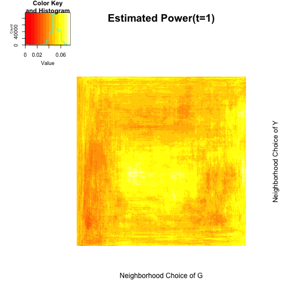

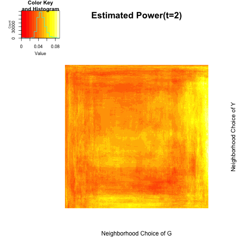

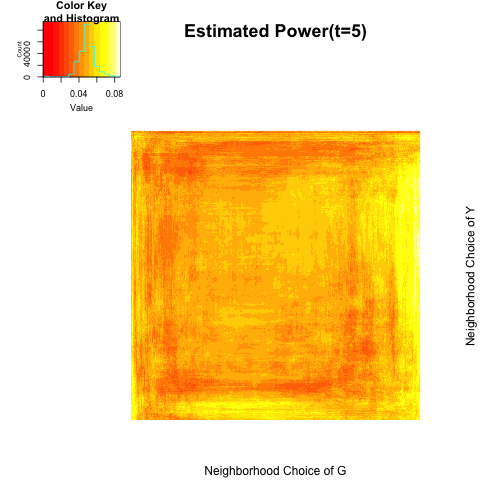

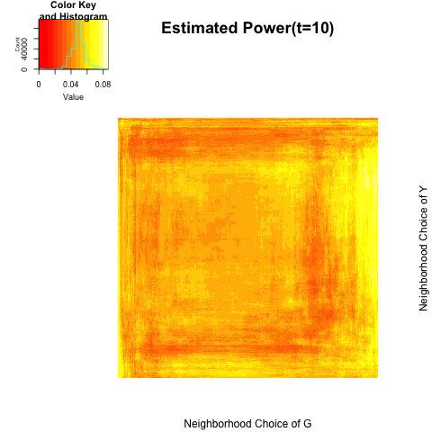

|  | t=1 | t=2 | t=5 | t=10 |
| --- | --- | --- | --- | --- |
| global test | 0.052 | 0.062 | 0.062 | 0.056 |
| local optimal | 0.076 | 0.090 | 0.086 | 0.086 |

2. $\rho = 0.1$

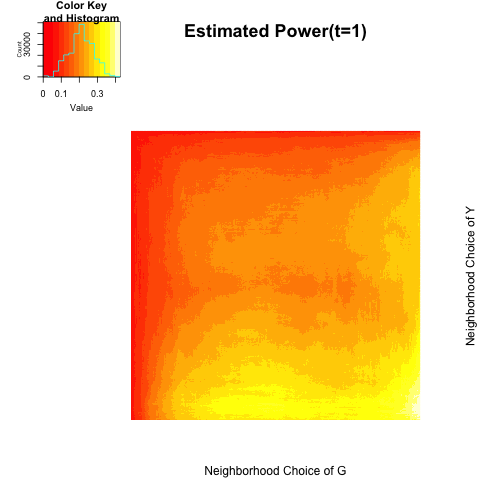

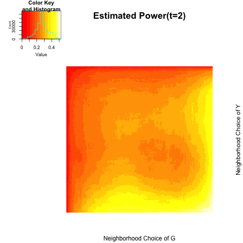

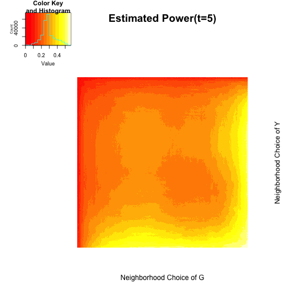

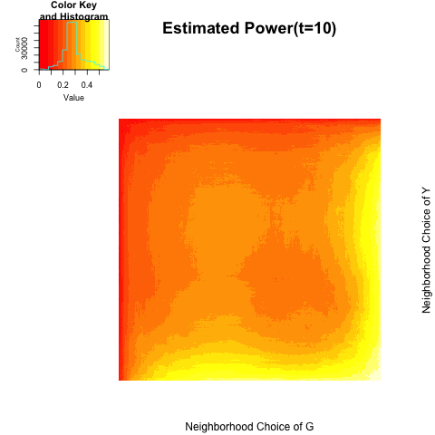

|  | t=1 | t=2 | t=5 | t=10 |
| --- | --- | --- | --- | --- |
| global test | 0.376 | 0.520 | 0.564 | 0.574 |
| local optimal | 0.426 | 0.522 | 0.570 | 0.580 |

3. $\rho = 0.2$

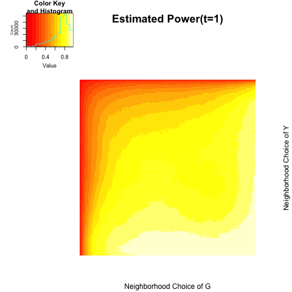

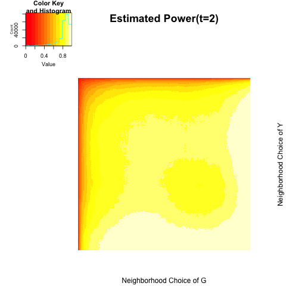

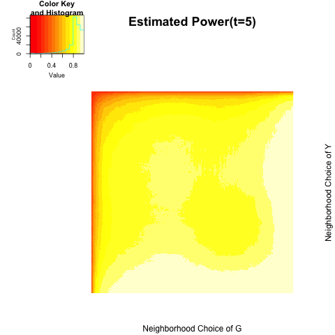

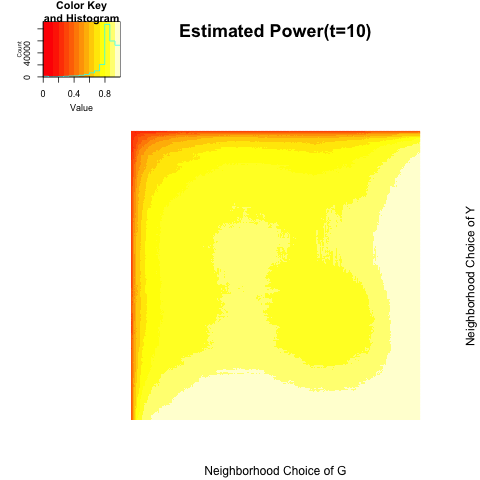

|  | t=1 | t=2 | t=5 | t=10 |
| --- | --- | --- | --- | --- |
| global test | 0.954 | 0.984 | 0.992 | 0.992 |
| local optimal | 0.974 | 0.988 | 0.994 | 0.996 |

## Multivariate Attributes

$(X_1, Y_{11}, Y_{12}, Y_{13}), ... , (X_N, Y_{1N}, Y_{2N}, Y_{3N}) \overset{i.i.d}{\sim} N \left( \begin{bmatrix} 0 \\ 0 \\ 0 \\ 0 \end{bmatrix}, \begin{bmatrix}1 & \rho_{1} & \rho_{2}& \rho_{3} \\ \rho_{1} & 1 & 0 & 0 \\ \rho_{2} & 0 & 1 & 0 \\ \rho_{3} & 0 & 0 & 1 \end{bmatrix} \right)$

1. $\rho = (\rho_{1}, \rho_{2}, \rho_{3}) = (0.0, 0.0, 0.0)$

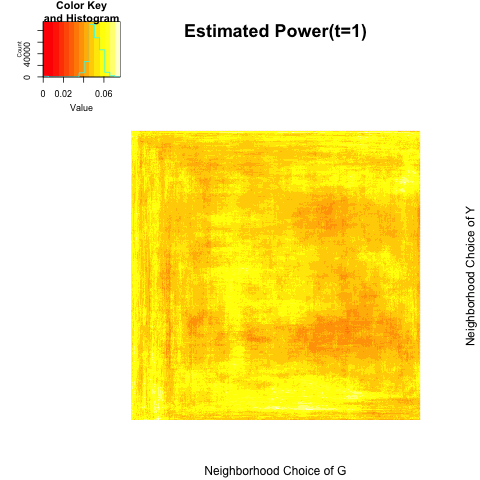

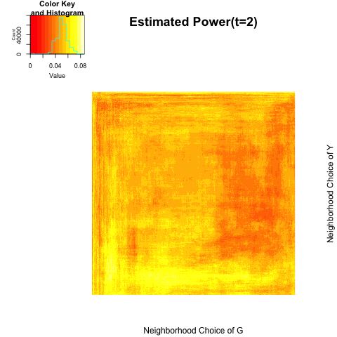

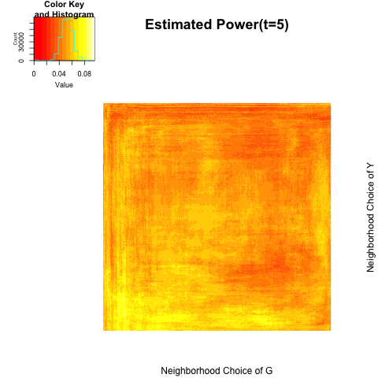

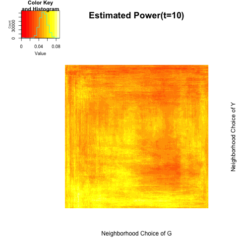

|  | t=1 | t=2 | t=5 | t=10 |
| --- | --- | --- | --- | --- |
| global test | 0.040 | 0.056 | 0.054 | 0.062 |
| local optimal | 0.076 | 0.086 | 0.096 | 0.088 |

2. $\rho = (\rho_{1}, \rho_{2}, \rho_{3}) = (0.1, 0.1, 0.1)$

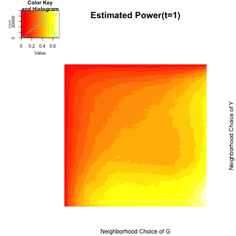

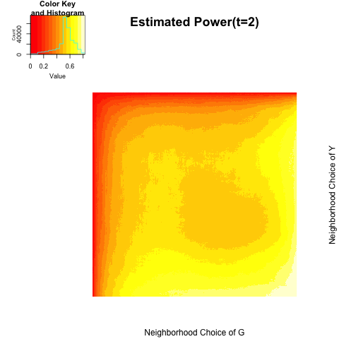

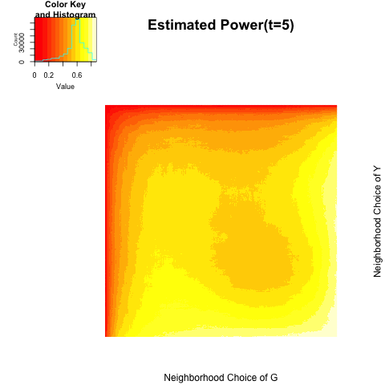

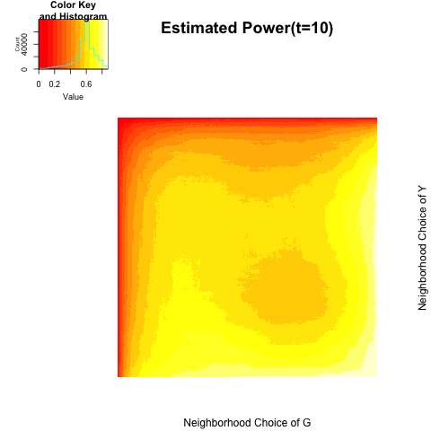

|  | t=1 | t=2 | t=5 | t=10 |
| --- | --- | --- | --- | --- |
| global test | 0.664 | 0.822 | 0.870 | 0.872 |
| local optimal | 0.718 | 0.826 | 0.872 | 0.872 |

3. $\rho = (\rho_{1}, \rho_{2}, \rho_{3}) = (0.2, 0.2, 0.2)$

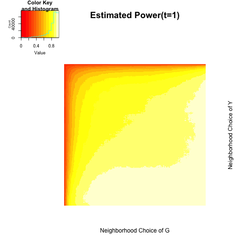

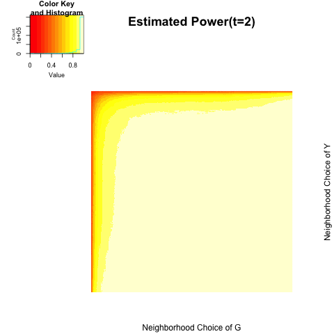

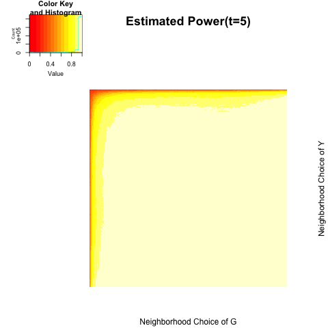

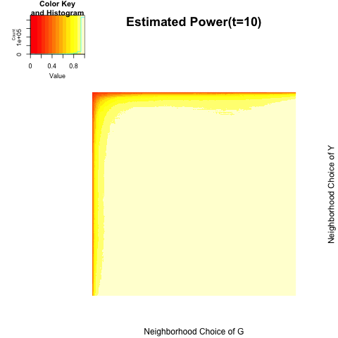

|  | t=1 | t=2 | t=5 | t=10 |
| --- | --- | --- | --- | --- |
| global test | 0.998 | 1 | 1 | 1 |
| local optimal | 1.000 | 1 | 1 | 1 |

4. $\rho = (\rho_{1}, \rho_{2}, \rho_{3}) = (0.2, -0.2, 0.0)$

[figure not shown]

[figure not shown]

[figure not shown]

[figure not shown]

|  | t=1 | t=2 | t=5 | t=10 |
| --- | --- | --- | --- | --- |
| global test | 0.984 | 0.998 | 1 | 0.998 |
| local optimal | 0.992 | 0.998 | 1 | 1.000 |